# GradientBoostedTrees

Raman Kannan

10/5/2020

# Boosting

In Boosting is an iterative method, similar to penalization, and in each iteration, we increase the weights of observations, for which the classifier fails to label correctly.

## Available boosting methods

- AdaBoost
- Extreme gradient boosting (XGBoost)
- gradient based boosting
- CatBoost
- LightGBM

# Boosting Trials

```r
require(gbm)
require(ROCR)
require(pROC)

file<-'c://Users/rk215/Data/heart.csv'
ibmfile<-'C:/data/heart.csv'
heart<-read.csv(file,head=T,sep=',',stringsAsFactors=F)

tridx<-sample(1:nrow(heart),0.7*nrow(heart),replace=F)
tstdata<-heart[-tridx,]
trdata<-heart[tridx,]
names(trdata)[[14]]
```

```
## [1] "target"
```

```r
gbm_heart_3<-gbm(target~.,data=trdata,
                 distribution="bernoulli",
                 n.trees=500,
                 shrinkage=0.01,
                 interaction.depth=3,
                 n.minobsinnode=10,
                 verbose=T,
                 keep.data=F)
#Gradient tree boosting implementations often also #use regularization by limiting the minimum number #of observations in trees' terminal nodes. It is #used in the tree building process by ignoring any #splits that lead to nodes containing fewer than #this number of training set instances.

#Imposing this limit helps to reduce variance in #predictions at leaves.

gbm_predict<-predict(gbm_heart_3,
                     tstdata[,-c(14)],
                    type="response",
                    gbm_heart_3$n.trees)


gbm_predicted<-round(gbm_predict)

gbm_prediction<-prediction(gbm_predicted,
                           tstdata$target)

(gbm_tbl<-table(tstdata$target,gbm_predicted))
```

```
##    gbm_predicted
##      0  1
##   0 38  7
##   1  5 41
```

```r
(gbm_cfm<-caret::confusionMatrix(gbm_tbl))
```

```
## Confusion Matrix and Statistics
##
##    gbm_predicted
##      0  1
##   0 38  7
##   1  5 41
##
##                Accuracy : 0.8681
##                  95% CI : (0.781, 0.93)
##     No Information Rate : 0.5275
##     P-Value [Acc > NIR] : 5.296e-12
##
##                   Kappa : 0.7361
##
##  Mcnemar's Test P-Value : 0.7728
##
##             Sensitivity : 0.8837
##             Specificity : 0.8542
##          Pos Pred Value : 0.8444
##          Neg Pred Value : 0.8913
##              Prevalence : 0.4725
##          Detection Rate : 0.4176
##    Detection Prevalence : 0.4945
##       Balanced Accuracy : 0.8689
##
##        'Positive' Class : 0
##
```

```r
gbm_perf<-performance(gbm_prediction,
                      measure="tpr",
                      x.measure="fpr")
(gbm_auc<-performance(gbm_prediction,
                     measure="auc"))@y.values[[1]]
```

```
## [1] 0.8678744
```

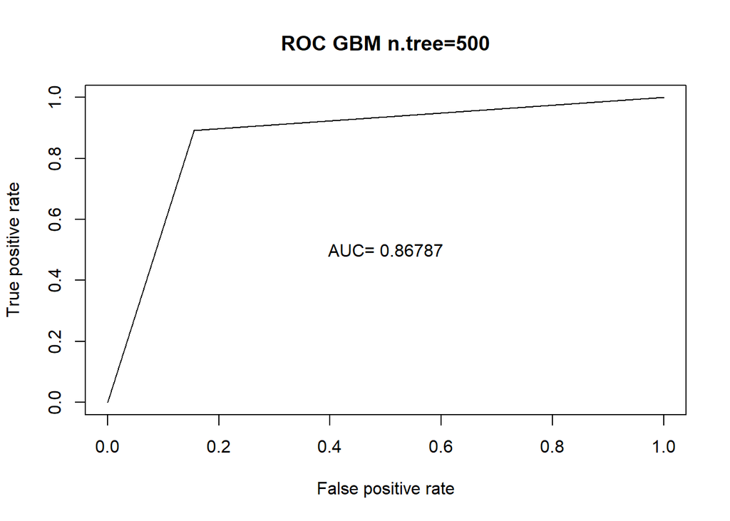

```r
plot(gbm_perf,main="ROC GBM n.tree=500")
text(0.5,0.5,paste("AUC=",format(gbm_auc@y.values[[1]],digits=5, scientific=FALSE)))
```

## Business of plotting ROC The above ROC Curve plot is not sufficient as it has three probabilities, including, {0,1}. We can use pROC package which is far easier to work with, as shown below.

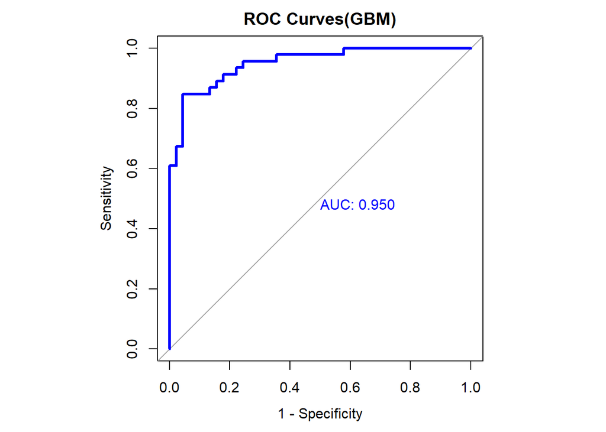

```r
par(pty="s")
gbm_roc<-roc(tstdata$target~gbm_predict,
             plot=TRUE,
             print.auc=TRUE,
             col='blue',
             lwd=3,
             legacy.axes=TRUE,
             main='ROC Curves(GBM)')
```

```r
gbm_auc<-auc(gbm_roc)
```

Now let us run xgboost

```r
require(xgboost)
require(Matrix)

trdatamx<-sparse.model.matrix(target~.-1,data=trdata)

tstdatamx<-sparse.model.matrix(target~.-1,data=tstdata)

xgb_model<-xgboost(data=trdatamx,
                   label=trdata$target,
                   max_depth = 2,
  eta = 1,
  nrounds = 2,
  nthread = 2,
  #objective = "multi:softmax",# to get classes
  objective = "multi:softprob",# to get probs
  num_class=2)
#xgb_pred <- predict(xgb_model,tstdatamx,type='response')

xgb_pred <- predict(xgb_model,tstdatamx)
xgb_pred_df<-data.frame(actual=tstdata$target,
prob.1=xgb_pred[seq(0,length(xgb_pred),by=2)],    prob.0=xgb_pred[seq(1,length(xgb_pred),by=2)])
xgb_pred_class<-ifelse(xgb_pred_df$prob.0>xgb_pred_df$prob.1,0,1)
TN<-xgb_pred[(xgb_pred_class==1)&(xgb_pred==tstdata$target)]
TP<-xgb_pred[(xgb_pred_class==0)&(xgb_pred==tstdata$target)]
(xgb_tbl<-table(tstdata$target,xgb_pred_class))
```

```
##    xgb_pred_class
##      0  1
##   0 34 11
##   1 10 36
```

```r
(xgb_cfm<-caret::confusionMatrix(xgb_tbl))
```

```
## Confusion Matrix and Statistics
##
##    xgb_pred_class
##      0  1
##   0 34 11
##   1 10 36
##
##                Accuracy : 0.7692
##                  95% CI : (0.6691, 0.8511)
##     No Information Rate : 0.5165
##     P-Value [Acc > NIR] : 6.174e-07
##
##                   Kappa : 0.5383
##
##  Mcnemar's Test P-Value : 1
##
##             Sensitivity : 0.7727
##             Specificity : 0.7660
##          Pos Pred Value : 0.7556
##          Neg Pred Value : 0.7826
##              Prevalence : 0.4835
##          Detection Rate : 0.3736
##    Detection Prevalence : 0.4945
##       Balanced Accuracy : 0.7693
##
##        'Positive' Class : 0
##
```

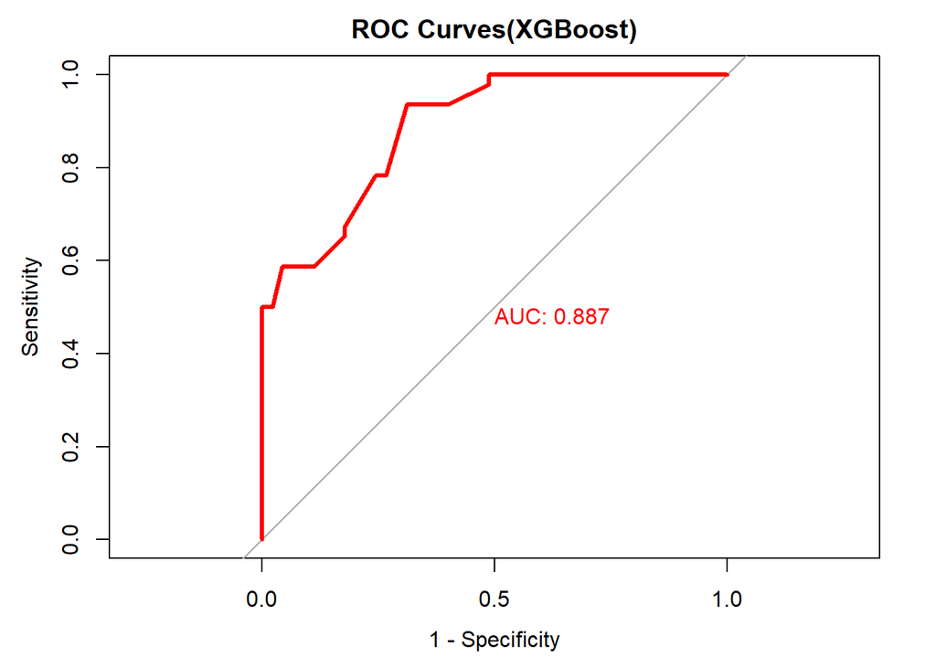

```r
#str(xgb_pred)

xgb_roc<-roc(tstdata$target~xgb_pred[seq(0,length(xgb_pred),by=2)],
             plot=TRUE,
             print.auc=TRUE,
             col='red',
             lwd=3,
             legacy.axes=TRUE,
             main='ROC Curves(XGBoost)')
```

```r
xgb_auc<-auc(xgb_roc)
```

## Comparison with GLM

How different are these estimates? let us run glm and get the estimates…

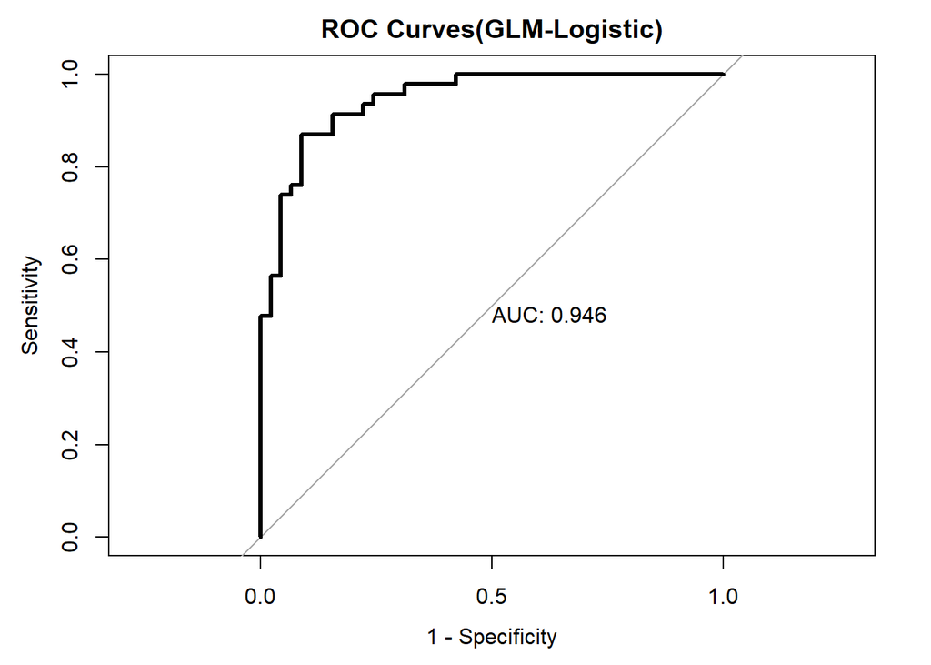

```r
glm.model<-glm(target~.,data=trdata,family='binomial')

glm.pred<-predict(glm.model,
                  tstdata[,-c(14)],
                  type='response')
glm.class<-ifelse(glm.pred<0.50,0,1)
glm_tbl<-table(tstdata$target,glm.class)
glm_cfm<-caret::confusionMatrix(glm_tbl)



glm_roc<-roc(tstdata$target~glm.pred,
             plot=TRUE,
             print.auc=TRUE,
             col='black',
             lwd=3,
             legacy.axes=TRUE,
             main='ROC Curves(GLM-Logistic)')
```

```r
glm_auc<-auc(glm_roc)
```

## Comparative Analysis

Let us review the performance (standard metrics) for GLM,GBM and XGBoost.

```r
accuracy<-function(xt)sum(diag(xt))/sum(xt)

gbm_tbl
```

```
##    gbm_predicted
##      0  1
##   0 38  7
##   1  5 41
```

```r
gbm_cfm
```

```
## Confusion Matrix and Statistics
##
##    gbm_predicted
##      0  1
##   0 38  7
##   1  5 41
##
##                Accuracy : 0.8681
##                  95% CI : (0.781, 0.93)
##     No Information Rate : 0.5275
##     P-Value [Acc > NIR] : 5.296e-12
##
##                   Kappa : 0.7361
##
##  Mcnemar's Test P-Value : 0.7728
##
##             Sensitivity : 0.8837
##             Specificity : 0.8542
##          Pos Pred Value : 0.8444
##          Neg Pred Value : 0.8913
##              Prevalence : 0.4725
##          Detection Rate : 0.4176
##    Detection Prevalence : 0.4945
##       Balanced Accuracy : 0.8689
##
##        'Positive' Class : 0
##
```

```r
glm_tbl
```

```
##    glm.class
##      0  1
##   0 38  7
##   1  6 40
```

```r
glm_cfm
```

```
## Confusion Matrix and Statistics
##
##    glm.class
##      0  1
##   0 38  7
##   1  6 40
##
##                Accuracy : 0.8571
##                  95% CI : (0.7681, 0.9217)
##     No Information Rate : 0.5165
##     P-Value [Acc > NIR] : 7.599e-12
##
##                   Kappa : 0.7142
##
##  Mcnemar's Test P-Value : 1
##
##             Sensitivity : 0.8636
##             Specificity : 0.8511
##          Pos Pred Value : 0.8444
##          Neg Pred Value : 0.8696
##              Prevalence : 0.4835
##          Detection Rate : 0.4176
##    Detection Prevalence : 0.4945
##       Balanced Accuracy : 0.8574
##
##        'Positive' Class : 0
##
```

```r
xgb_tbl
```

```
##    xgb_pred_class
##      0  1
##   0 34 11
##   1 10 36
```

```r
xgb_cfm
```

```
## Confusion Matrix and Statistics
##
##    xgb_pred_class
##      0  1
##   0 34 11
##   1 10 36
##
##                Accuracy : 0.7692
##                  95% CI : (0.6691, 0.8511)
##     No Information Rate : 0.5165
##     P-Value [Acc > NIR] : 6.174e-07
##
##                   Kappa : 0.5383
##
##  Mcnemar's Test P-Value : 1
##
##             Sensitivity : 0.7727
##             Specificity : 0.7660
##          Pos Pred Value : 0.7556
##          Neg Pred Value : 0.7826
##              Prevalence : 0.4835
##          Detection Rate : 0.3736
##    Detection Prevalence : 0.4945
##       Balanced Accuracy : 0.7693
##
##        'Positive' Class : 0
##
```

```r
gbm_acc<-accuracy(gbm_tbl)
glm_acc<-accuracy(glm_tbl)
xgb_acc<-accuracy(xgb_tbl)
print(paste("gbm:",gbm_acc,sep=""))
```

```
## [1] "gbm:0.868131868131868"
```

```r
print(paste("glm:",glm_acc,sep=""))
```

```
## [1] "glm:0.857142857142857"
```

```r
print(paste("xgb:",xgb_acc,sep=""))
```

```
## [1] "xgb:0.769230769230769"
```

```r
perfdf<-data.frame(algo=c("glm","gbm","xgb"),
                   acc=c(glm_acc,gbm_acc,xgb_acc),
                   auc=c(glm_auc,gbm_auc,xgb_auc))
```

## Stacking

For stacking we can run another meta learner where the dependent variable is actual and the independent variables are the predictions from the different classifiers.

```r
stackeddf<-data.frame(actual=tstdata$target,
                      glmpred=glm.class,
                      gbmpred=gbm_predicted,
                      xgbpred=xgb_pred_class)

head(stackeddf)
```

```
##    actual glmpred gbmpred xgbpred
## 4       1       1       1       1
## 9       1       1       1       1
## 11      1       0       1       0
## 13      1       1       1       1
## 16      1       1       1       1
## 22      1       1       1       1
```

```r
tail(stackeddf)
```

```
##     actual glmpred gbmpred xgbpred
## 279      0       1       1       1
## 285      0       0       0       0
## 295      0       0       0       0
## 298      0       0       0       0
## 300      0       1       1       1
## 302      0       0       0       0
```

Or we can take the majority vote as follows

```r
stacked_mean<-unlist(apply(stackeddf[,2:4],1,mean))
#round()
stacked_label<-ifelse(stacked_mean<0.5,0,1)
stackeddf<-cbind(stackeddf,stacked=stacked_label)
(stbl<-table(stackeddf$actual,stacked_label))
```

```
##    stacked_label
##      0  1
##   0 39  6
##   1  5 41
```

```r
(scfm<-caret::confusionMatrix(stbl))
```

```
## Confusion Matrix and Statistics
##
##    stacked_label
##      0  1
##   0 39  6
##   1  5 41
##
##                Accuracy : 0.8791
##                  95% CI : (0.794, 0.9381)
##     No Information Rate : 0.5165
##     P-Value [Acc > NIR] : 2.065e-13
##
##                   Kappa : 0.7582
##
##  Mcnemar's Test P-Value : 1
##
##             Sensitivity : 0.8864
##             Specificity : 0.8723
##          Pos Pred Value : 0.8667
##          Neg Pred Value : 0.8913
##              Prevalence : 0.4835
##          Detection Rate : 0.4286
##    Detection Prevalence : 0.4945
##       Balanced Accuracy : 0.8794
##
##        'Positive' Class : 0
##
```

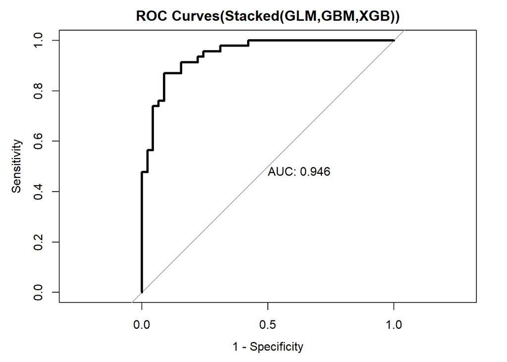

```r
stk_acc<-sum(diag(stbl))/sum(stbl)

stk_pred_prob<-(xgb_pred[seq(0,length(xgb_pred),by=2)]+
                           glm.pred+gbm_predict)/3

stk_roc<-roc(tstdata$target~glm.pred,
             plot=TRUE,
             print.auc=TRUE,
             col='black',
             lwd=3,
             legacy.axes=TRUE,
             main='ROC Curves(Stacked(GLM,GBM,XGB))')
```

```r
stk_auc<-auc(stk_roc)

perfdf<-rbind(perfdf,c("STK",stk_acc,stk_auc))

perfdf
```

```
##   algo               acc               auc
## 1  glm 0.857142857142857 0.946376811594203
## 2  gbm 0.868131868131868  0.95024154589372
## 3  xgb 0.769230769230769  0.88695652173913
## 4  STK 0.879120879120879 0.946376811594203
```

The improvement is anemic. Giving all three learners equal weight is not useful and so we might entertain giving them weights. And, thus, there are many interesting experiments we can undertake.

For now, we have finally, reached the end of our ML trail. We have introduced numerous ideas from Machine Learning and we have see computational techniques, if only you can focus on the moon and not on the pointer.

# Conclusion

From a Big Data perspective, notice that boosting is iterative and parallelizing boosting is either non-trivial or impossible. In the next lecture, we will review Big Data and Machine Learning and reserve the rest for student feed back.

During the course I have used absolute numbers and they are NOT rules. You can change them working with your stake-holders. That is what I use and I make that part of ALL my SOW.